# HSC Survey Results

# German Bank Survey # 7 Results from 03/11/2024

## Survey Details

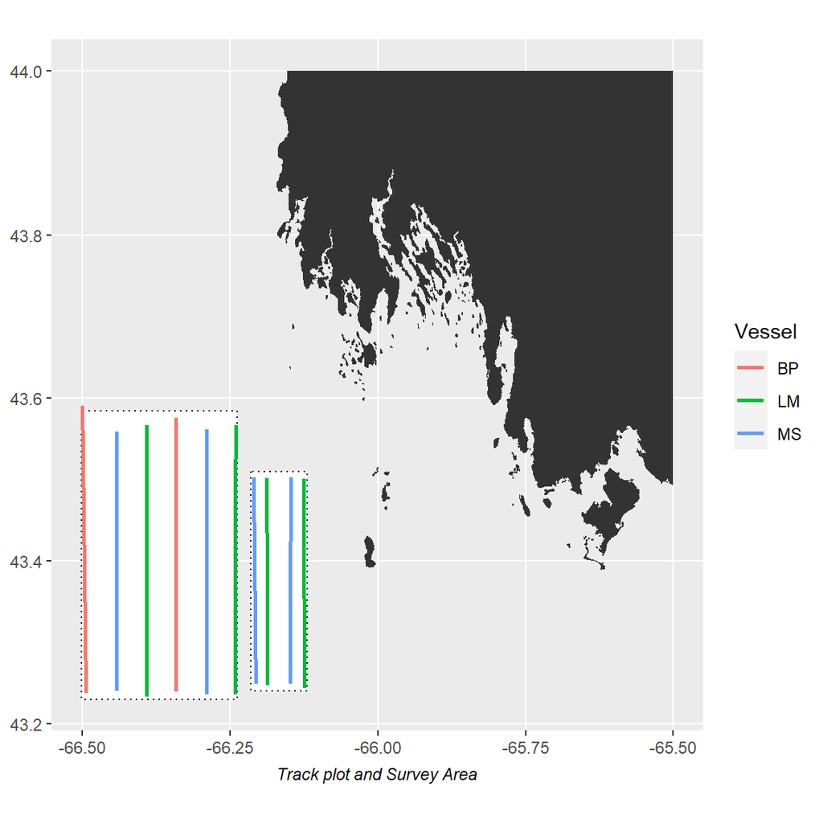

3 commercial purse seiners conducted this fishing survey on 03/11/2024 starting at 18:00:00.

The Morning Star and the Lady Melissa were able to complete two transects each in the German Bank and Seal Island Box. The Brunswick Provider completed two transects in the German Bank box but were unable to complete the lines in Seal Island due to problems with the boat and weather..

There was a plankton tow and replicate conducted and CTD cast by Lady Melissa.

No tags were applied during this survey.

Since no fish were caught, no samples were obtained for target strength estimation.

### Acoustic Equipment

Each vessel was equipped with a Simrad ES38-18/200-18C combi (2-in-1) transducer prior to the survey that contains a 38kHz split beam and 200 kHz single beam transducer. Data was logged to the computer hard-drive for post-processing. All participating boats were calibrated on 38kHz before the survey.

## Survey Results

### Main Results

The results are subject to change as DFO will re-evaluate data editing, area estimation and apply a target strength.

**Preliminary biomass prediction for German Bank using standardized parallel transects is 3,004mt, and with turnover applied 1,999mt. The preliminary biomass estimate for Seal Island is 1,089mt.**

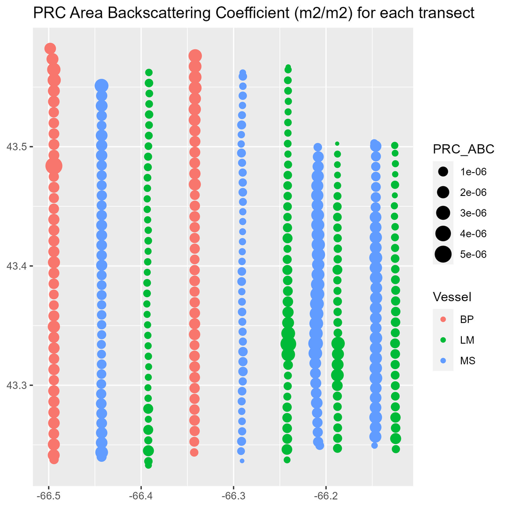

### Transect Details

Table 1: Transect Details

| Vessel | Transect # | Date/Time Start | Date/Time End | Start Lon | Start Lat | End Lon | End Lat | Location | Distance (km) | Speed |
| --- | --- | --- | --- | --- | --- | --- | --- | --- | --- | --- |
| BP | T01 | 2024-11-03 17:51:43 | 2024-11-03 20:00:22 | -66.500 | 43.591 | -66.494 | 43.238 | GB | 39.40 | 9.92 |
| BP | T02 | 2024-11-03 20:43:05 | 2024-11-03 22:42:19 | -66.343 | 43.239 | -66.342 | 43.576 | GB | 37.47 | 10.18 |
| LM | T02 | 2024-11-03 21:50:09 | 2024-11-04 00:16:06 | -66.242 | 43.236 | -66.241 | 43.567 | GB | 37.39 | 8.30 |
| LM | T01 | 2024-11-03 18:39:37 | 2024-11-03 21:07:45 | -66.392 | 43.567 | -66.392 | 43.233 | GB | 37.94 | 8.30 |
| LM | T03 | 2024-11-04 00:47:48 | 2024-11-04 02:36:14 | -66.188 | 43.503 | -66.188 | 43.247 | GB | 28.96 | 8.65 |
| LM | T04 | 2024-11-04 02:53:58 | 2024-11-04 04:46:35 | -66.124 | 43.243 | -66.126 | 43.501 | GB | 29.08 | 8.37 |
| MS | T01 | 2024-11-03 18:48:57 | 2024-11-03 21:09:24 | -66.443 | 43.559 | -66.443 | 43.240 | GB | 38.46 | 8.87 |
| MS | T02 | 2024-11-03 22:01:23 | 2024-11-04 00:24:17 | -66.290 | 43.236 | -66.290 | 43.562 | GB | 39.50 | 8.96 |
| MS | T03 | 2024-11-04 01:07:30 | 2024-11-04 02:56:24 | -66.210 | 43.503 | -66.207 | 43.249 | GB | 30.86 | 9.18 |
| MS | T04 | 2024-11-04 03:15:50 | 2024-11-04 05:22:55 | -66.148 | 43.249 | -66.148 | 43.503 | GB | 30.47 | 7.77 |

### Survey Summary

Table 2: Acoustic Survey Results

| Vessel | Transect No. | Target Strength (db/kg) | Mean Sa (/m2) | Biomass Density (kg/m2) |
| --- | --- | --- | --- | --- |
| MS | T03 | -35.5 | -56.930 | 0.007 |
| MS | T04 | -35.5 | -57.536 | 0.006 |
| BP | T01 | -35.5 | -57.983 | 0.006 |
| BP | T02 | -35.5 | -58.522 | 0.005 |
| MS | T01 | -35.5 | -59.047 | 0.004 |
| LM | T02 | -35.5 | -60.449 | 0.003 |
| LM | T03 | -35.5 | -61.061 | 0.003 |
| LM | T04 | -35.5 | -62.116 | 0.002 |
| MS | T02 | -35.5 | -63.314 | 0.002 |
| LM | T01 | -35.5 | -63.858 | 0.001 |

Note:  
Transects are listed from greatest to least backscatter.

Table 3: Survey Summary Table

| Layer | Target Strength | Area (km2) | Mean Sa | Density (kg/m2) | Biomass (tons) | Percent Area | Percent Biomass | Standard Error (tons) | Standard Error (%) |
| --- | --- | --- | --- | --- | --- | --- | --- | --- | --- |
| German Bank | -35.5 | 844 | -59.9847 | 0.0036 | 3,004 | 78.4 | 73.4 | 602.35 | 20.05 |
| Seal Island | -35.5 | 233 | -58.8139 | 0.0046 | 1,089 | 21.6 | 26.6 | 291.09 | 26.74 |

### Greatest Biomass Densities

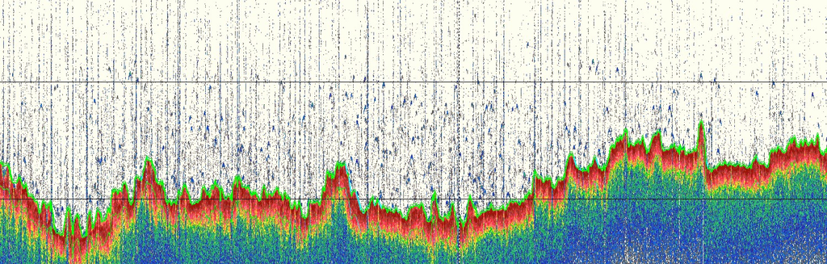

A snip from the transect with the greatest biomass density (kg/m2)

The single point with the largest biomass density (kg/m2) was recorded by **BP**, at the following location:

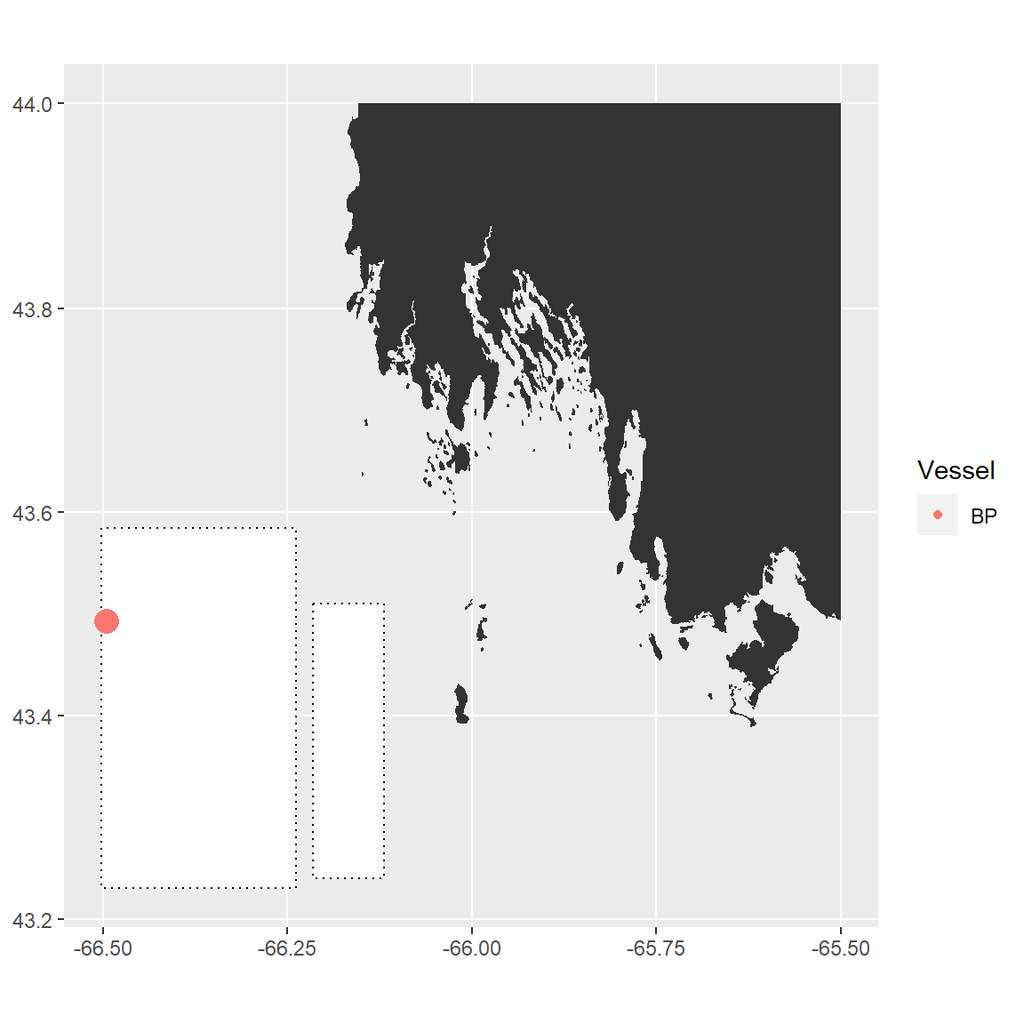

The transect with the greatest average biomass density (kg/m2) was recorded by **MS**, at the following location:

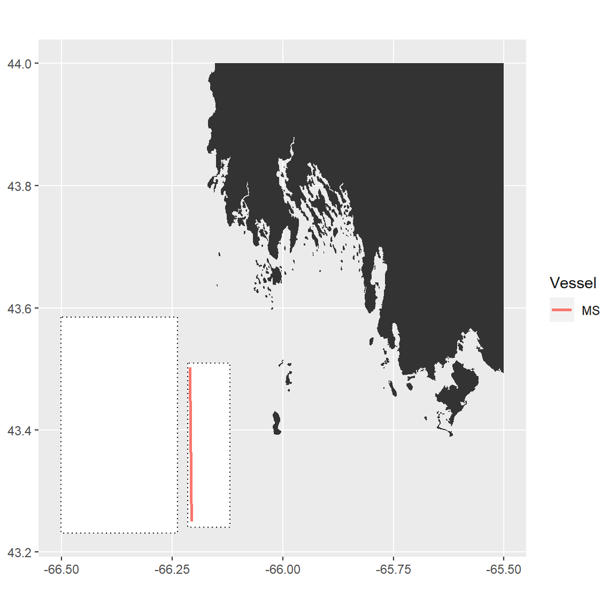

### Annual Summaries

This table does not include the biomass from adhoc surveys.

Table 4: Annual Comparison Table

| Ground | Survey Number | Current Year Survey Date | Current Year HSC Estimate | Current Year HSC Turnover Adjusted | Previous Year Survey Date | Previous Year HSC Estimate | Previous Year HSC Turnover Adjusted | Previous Year DFO Estimate | Previous Year DFO Turnover Adjusted |
| --- | --- | --- | --- | --- | --- | --- | --- | --- | --- |
| German Bank | 1 | 2024-08-04 | 12,233 | 12,233 | 2023-08-06 | 2,687 | 2,687 | 2,021 | 2,021 |
| Seal Island | 1 | 2024-08-04 | 45,930 | NA | 2023-08-06 | 1,205 | NA | 929 | NA |
| German Bank | 2 | 2024-08-18 | 14,054 | 11,668 | 2023-08-20 | 4,930 | 4,406 | 3,282 | 2,887 |
| Seal Island | 2 | 2024-08-18 | 6,285 | NA | 2023-08-20 | 1,918 | NA | 897 | NA |
| German Bank | 3 | 2024-09-02 | 15,499 | 12,639 | 2023-09-03 | 9,959 | 8,901 | 8,372 | 7,660 |
| Seal Island | 3 | 2024-09-02 | 3,770 | NA | 2023-09-03 | 2,063 | NA | 1,099 | NA |
| German Bank | 4 | 2024-09-15 | 24,824 | 21,033 | 2023-09-13 | 16,266 | 13,203 | 15,011 | 12,498 |
| Seal Island | 4 | 2024-09-15 | 1,369 | NA | 2023-09-13 | 5,636 | NA | 4,045 | NA |
| German Bank | 5 | 2024-09-29 | 10,595 | 5,068 | 2023-09-27 | 15,242 | 11,360 | 13,503 | 9,978 |
| Seal Island | 5 | 2024-09-29 | 3,134 | NA | 2023-09-27 | 53,844 | NA | 42,269 | NA |
| German Bank | 6 | 2024-10-20 | 5,151 | 4,071 | 2023-10-11 | 23,614 | 20,057 | 26,563 | 23,390 |
| Seal Island | 6 | 2024-10-20 | 2,927 | NA | 2023-10-11 | 15,261 | NA | 14,381 | NA |
| German Bank | 7 | 2024-11-03 | 3,004 | 1,999 | 2023-10-24 | 11,184 | 5,502 | 13,033 | 6,803 |
| Seal Island | 7 | 2024-11-03 | 1,089 | NA | 2023-10-24 | 1,006 | NA | 1,087 | NA |

Table 5: Annual Summary Table

| Year | Ground | HSC Estimate | HSC Turnover Adjusted | DFO Estimate | DFO Turnover Adjusted |
| --- | --- | --- | --- | --- | --- |
| 2023 | German Bank | 83,882 | 66,116 | 81,785 | 65,237 |
| 2023 | Seal Island | 80,933 | NA | 64,707 | NA |
| 2024 | German Bank | 85,360 | 68,711 | NA | NA |
| 2024 | Seal Island | 64,504 | NA | NA | NA |

## Tagging, Plankton, and CTD Data

### Summary map

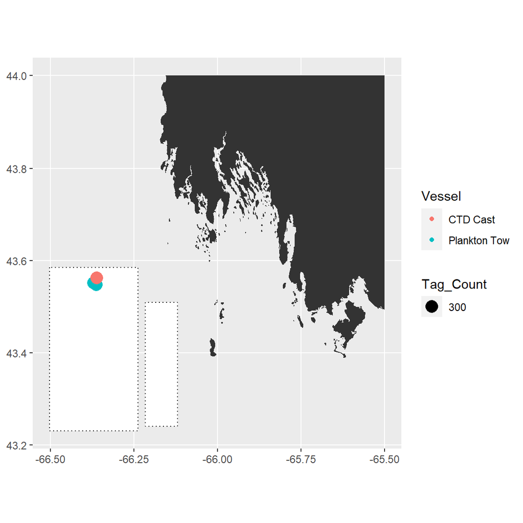

| Vessel | Tags |
| --- | --- |

### Plankton Data

#### Tow Summary Table

|  | Tow 1 | Tow 2 |
| --- | --- | --- |
| **Base Details** |  |  |
| Vessel | Lady Melissa | Lady Melissa |
| Set Number | GB2024-11 | GB2024-12 |
| Ground | GB | GB |
| Date | 03/11/2024 | 03/11/2024 |
| Wind Direction (km/h) | NW | NW |
| Swell (m) | 1 | 1 |
| Air Temp (c) | 2 | 2 |
| **Tow Details** |  |  |
| Tow Start | 17:17:00 | 17:32:00 |
| Tow End | 17:27:00 | 17:42:00 |
| Start Lat | 43.55167 | 43.54833 |
| End Lat | 43.54667 | 43.55667 |
| Start Lon | -66.37000 | -66.36167 |
| End Lon | -66.36833 | -66.35500 |
| Avg Tow Depth (m) | 3.807086 | 8.416952 |
| Speed | 6.4 | 3.4 |
| Heading | 180 | 9 |
| Tide Direction | with | against |
| **Other Data Collection** |  |  |
| Flow Start | 42673 | 94322 |
| Flow End | 94322 | 136936 |
| No. Revolutions | 51649 | 42614 |
| Distance (m) | 1387.964 | 1145.166 |
| Volume | 4360.288 | 3597.539 |
| Secchi Disappear (m) | NA | NA |
| Secchi Reappear (m) | NA | NA |

#### Tow Depth Profiles

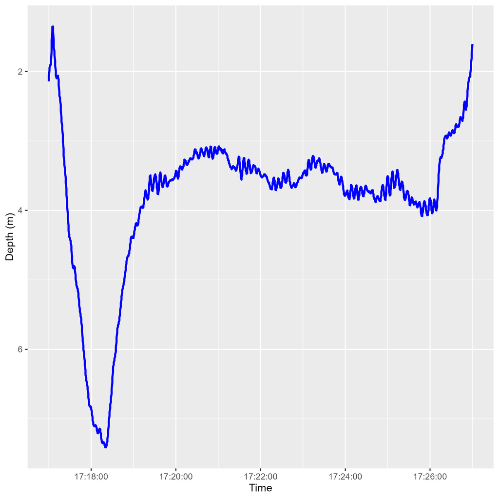

Plankton tow depth profile #1

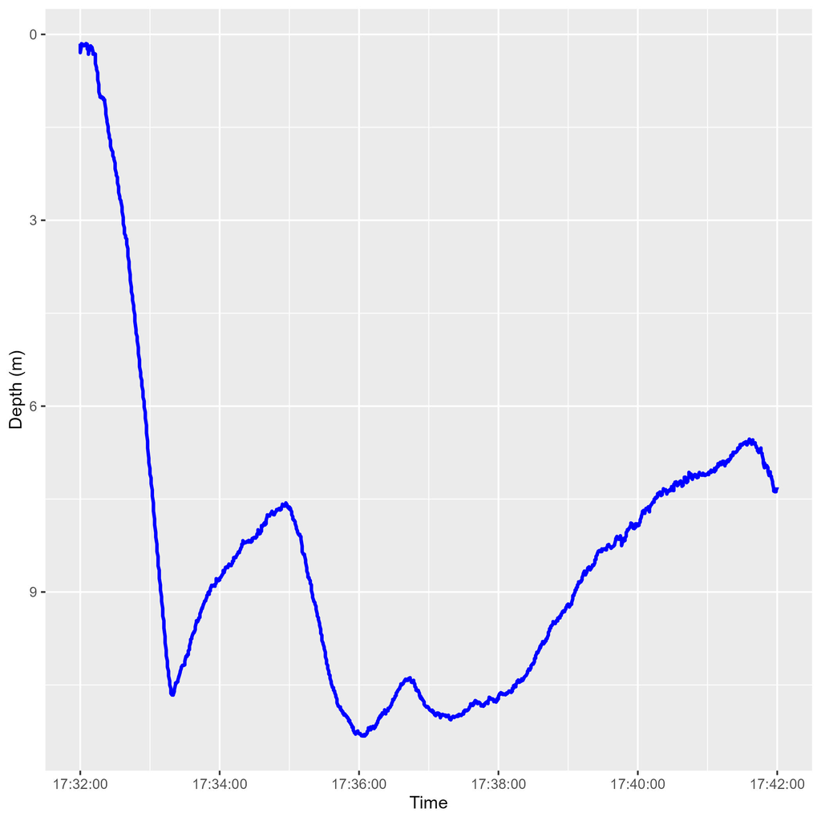

Plankton tow depth profile #2

The first tow is GB2024-11, which was with the tide and had an average depth of 3.8070862m. The second tow is GB2024-12, which was against the tide and had an average depth of 8.4169524m.

### CTD Data

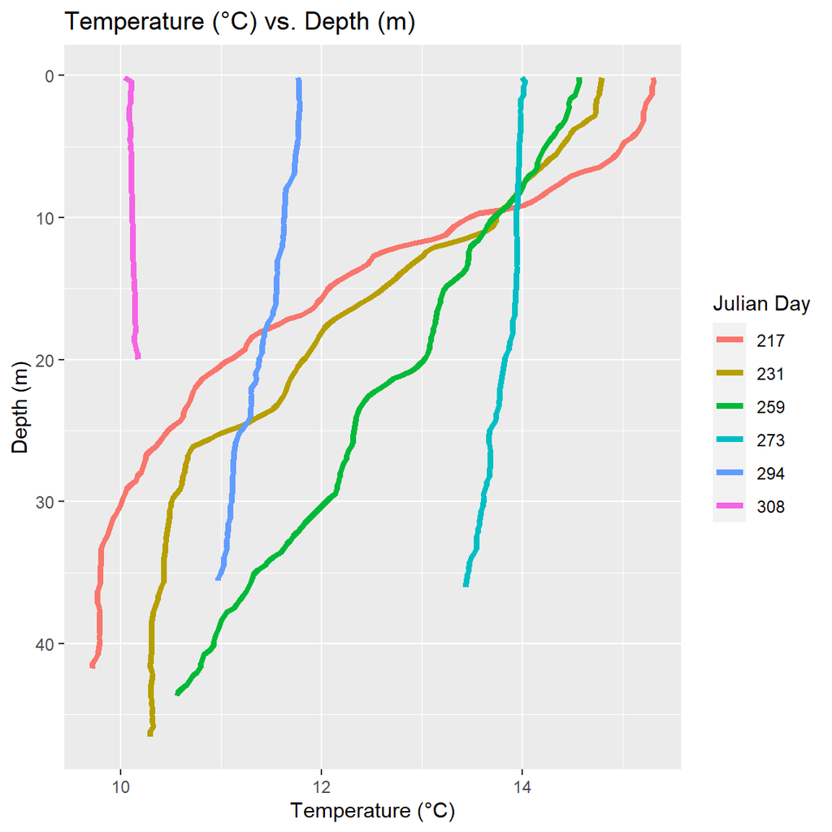

CTD depth profiles for all 2024 German Bank surveys so far.

#### Sea surface temperatures

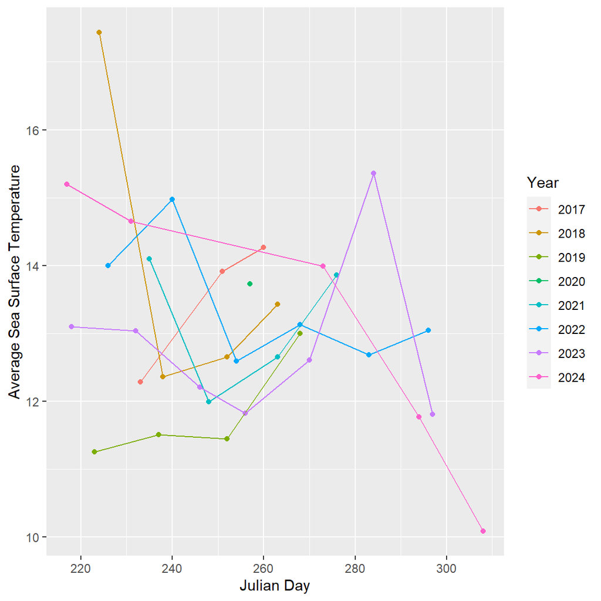

Annual average sea surface temperatures (SST) for German Bank.

## Vessel Performance

### Speed

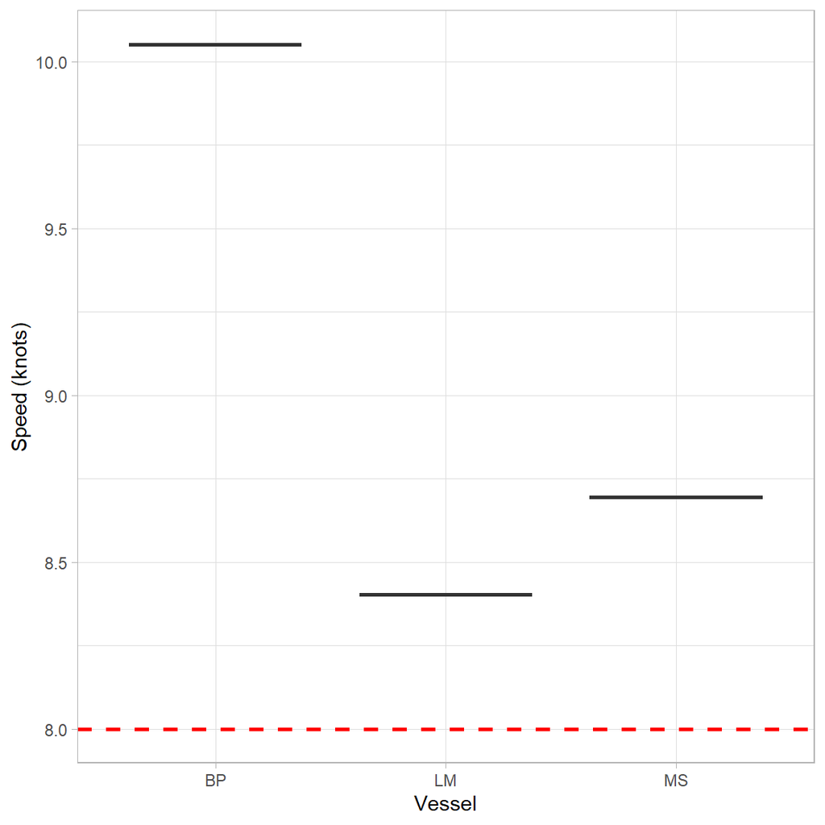

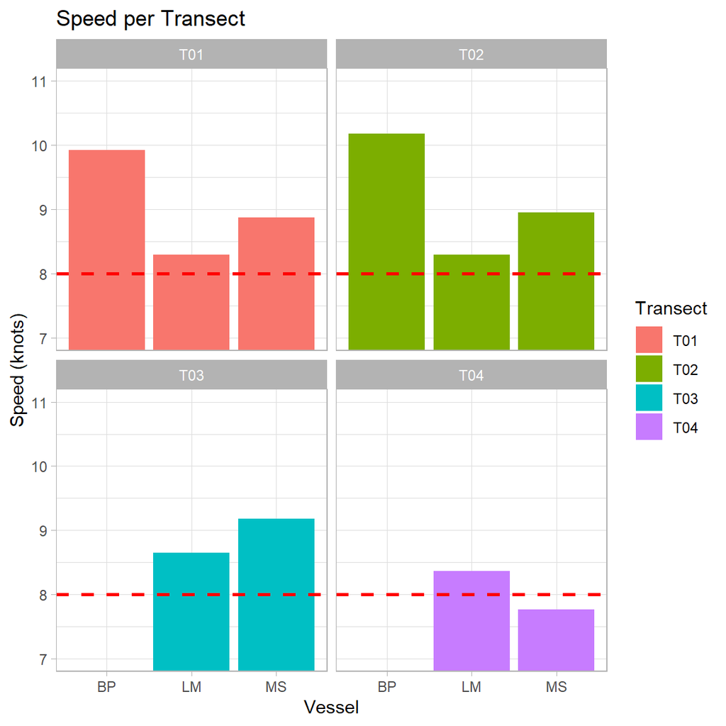

Average vessel speed was 9.05. This is above the 8 knot requirement; vessels are urged to slow down to prevent backscatter noise from interfering with the acoustic data.

The speed for each transect are rudimentary and are calculated based on distance. If a significant amount of distance is cut, the speed will appear slower.

### Distance

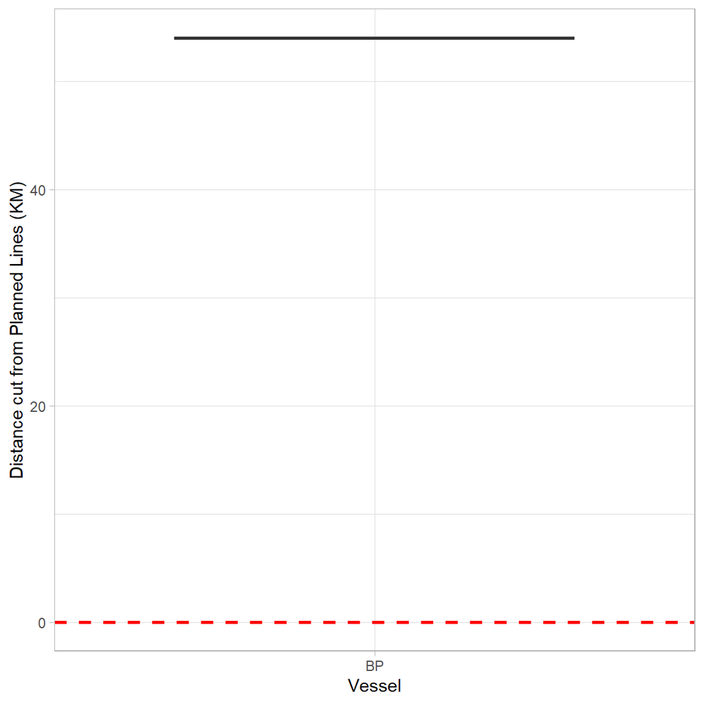

More than 2km of distance was cut from the planned lines; vessels are reminded to complete their assigned lines straight and without deviating or cutting corners short.